# Overview of Some Machine Learning Methods in R

Eddie Liu

November 9, 2019

# Bias-Variance

#### - Higher variance, lower bias

#### - (Non-linear) Training data lowest to highest MSE: High, Medium, Linear (variability)

#### - (Non-linear) Testing data lowest to highest MSE: Medium, High, Linear (variability)

#### - Small MSE_train, Large MSE_test = overfitting

#### - **Testing MSE is larger than Training MSE regardless of model**

#### - **Bias decreases more rapidly than variance increases until a certain point** Exception: F is linear (then bias doesn’t decrease as variance increases)

# K-Nearest Neighbor

#### - A training dataframe/ matrix with only predictors

#### - A vector of the training categorical response variable

#### - A testing dataframe with only predictors

```r
library(class)
set.seed(123)
data <- read.delim('banknote.txt')

#Sample 130 values for training data
i.train <- sample(1:nrow(data), 130, replace = F)

#Training dataset
#Testing dataset
#Remove response column
data.train <- data[i.train, -7]
data.test <- data[-i.train, -7]

#Vector of training response (Counterfeit in this case). Vector of testing response. Y = response column
counterfeit.train <- data[i.train, ]$Y
counterfeit.test <- data[-i.train, ]$Y
#Or
counterfeit.train <- data$Y[i.train]
counterfeit.test <- data$Y[-i.train]

#K = 1
m.knn <- knn(data.train, data.test, counterfeit.train, k=1)

table(m.knn, counterfeit.test)
```

```
##      counterfeit.test
## m.knn  0  1
##     0 33  0
##     1  0 37
```

```r
#K = 2
m.knn <- knn(data.train, data.test, counterfeit.train, k=2)

table(m.knn, counterfeit.test)
```

```
##      counterfeit.test
## m.knn  0  1
##     0 33  1
##     1  0 36
```

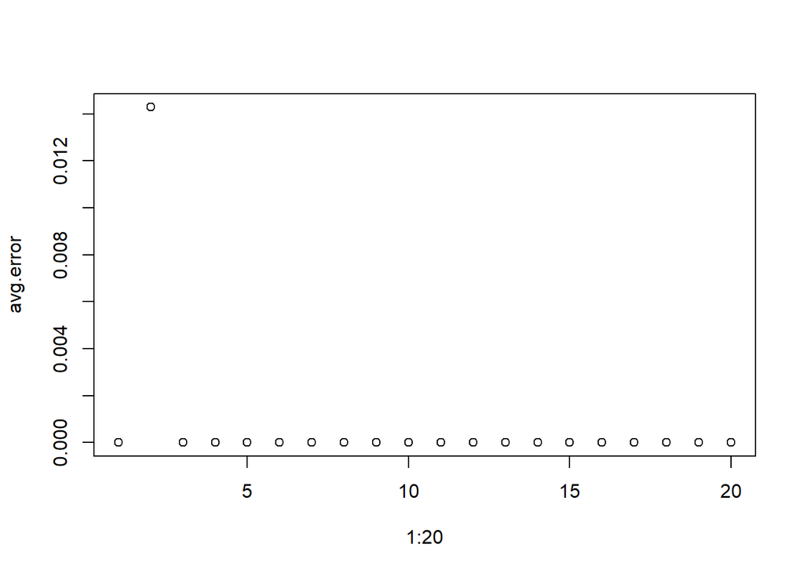

```r
#Compute misclassification error rate for k = 1:20
#Graph looks strange here because we have a variable (Diagonal) that does a very good job of classification
avg.error <- c()
for(k in 1:20){
  predictions <- knn(data.train, data.test, counterfeit.train, k)
  avg.error[k] <- mean(predictions != counterfeit.test)
}

plot(1:20, avg.error)
```

```r
#Standardize predictors
library(ISLR)
dim(Caravan)
```

```
## [1] 5822   86
```

```r
#Standardize predictors but not response
X <- Caravan[ ,-86]
X.standard <- scale(X)

set.seed(123)
test.i <- sample(1:nrow(Caravan), 1000, replace=F)

X.standard.test <- X.standard[test.i, ]
X.standard.train <- X.standard[-test.i, ]
Y.test <- Caravan$Purchase[test.i]
Y.train <- Caravan$Purchase[-test.i]

#K = 2
m.knn <- knn(X.standard.train, X.standard.test, Y.train, k=2)

table(m.knn, Y.test)
```

```
##      Y.test
## m.knn  No Yes
##   No  884  58
##   Yes  50   8
```

### Conceptual

#### - Higher K, less flexibility, greater bias

#### - KNN uses Euclidean distance and ignores units

#### - Standardize predictor variables

#### 2nd example see Lecture 2.2

# Logistic Regression

#### - Used for binary response variable

#### - Use log-odds because regular response variable Y is not linearly associated with x (but log-odds ratio is)

#### - Coefficient interpretation: a one-unit difference in x is associated with a multiplicative change in the odds of e^beta1

```r
data <- read.delim('banknote.txt')

#m1 estimates probability a banknote is counterfeit using the "Diagonal" variable, assuming 50-50 chance (0.5)
m1 <- glm(Y~Diagonal, data=data, family=binomial)
summary(m1)
```

```
##
## Call:
## glm(formula = Y ~ Diagonal, family = binomial, data = data)
##
## Deviance Residuals:
##     Min       1Q   Median       3Q      Max
## -3.5320  -0.0397  -0.0008   0.0440   1.5341
##
## Coefficients:
##             Estimate Std. Error z value Pr(>|z|)
## (Intercept)  989.547    219.465   4.509 6.52e-06 ***
## Diagonal      -7.044      1.562  -4.508 6.54e-06 ***
## ---
## Signif. codes:  0 '***' 0.001 '**' 0.01 '*' 0.05 '.' 0.1 ' ' 1
##
## (Dispersion parameter for binomial family taken to be 1)
##
##     Null deviance: 277.259  on 199  degrees of freedom
## Residual deviance:  21.109  on 198  degrees of freedom
## AIC: 25.109
##
## Number of Fisher Scoring iterations: 9
```

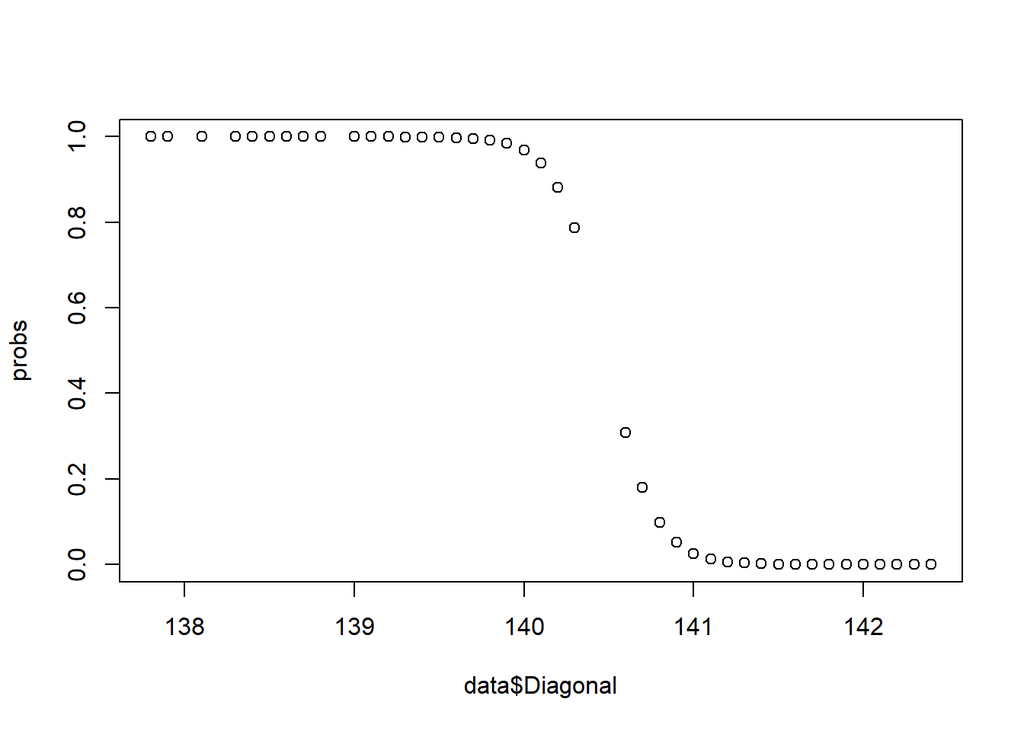

```r
#predict() defaults to predicted log-odds
probs <- predict(m1, type="response")
plot(probs~data$Diagonal)
```

```r
#m2 estimates probability a banknote is counterfeit using the "Left" variable, assuming 50-50 chance (0.5)
m2 <- glm(Y~Left, data=data, family=binomial)
probs <- predict(m2, type="response")
classification <- rep(0,200)
classification[probs > 0.5] <- 1
table(classification, data$Y)
```

```
##
## classification  0  1
##              0 73 26
##              1 27 74
```

#### - Can ‘tune’ the classifications by changing the probability threshold required to classify

# Linear Discriminant Analysis (LDA)

#### - Algorithm for implementing Bayes Classifier

#### - Finds best place to make the ‘cut’ to classify observations as belonging to 1 of 2 distributions

#### - Mislassification probability lowest for a linear split

#### - A greater number of parameters is associated with a model with higher variance and lower bias

#### - In theory, when all parameters are known and the model is correctly specified, this is the best approach to minimize testing error rate

# Bayes Classifier

#### - Most optimal if we do not have to estimate any quantities

#### - Assume distribution is gaussian for each category

#### - Assume standard deviation is the same for each category

#### - Assume prior probabilities of belonging to a category are equal

#### - LDA estimates group means for Bayes

```r
library(MASS)
set.seed(123)

data <- read.delim('banknote.txt')

#Split evenly
i.train <- sample(1:nrow(data), nrow(data)/2, replace=FALSE)
data.train <- data[i.train, ]
data.test <- data[-i.train, ]

#LDA model
lda.1 <- lda(Y~Diagonal, data=data.train)
lda.1
```

```
## Call:
## lda(Y ~ Diagonal, data = data.train)
##
## Prior probabilities of groups:
##    0    1
## 0.53 0.47
##
## Group means:
##   Diagonal
## 0 141.5377
## 1 139.3660
##
## Coefficients of linear discriminants:
##               LD1
## Diagonal 2.097743
```

```r
#Make predictions with training data
predictions.train <- predict(lda.1)
table(predictions.train$class, data.train$Y)
```

```
##
##      0  1
##   0 53  0
##   1  0 47
```

```r
#Evaluate predictive success on Testing Data
predictions.test <- predict(lda.1, newdata=data.test)
table(predictions.test$class, data.test$Y)
```

```
##
##      0  1
##   0 46  1
##   1  1 52
```

# Quadratic Discriminant Analysis (QDA)

#### - If we instead assumed that each group had its own variance and covariance terms

```r
library(MASS)
set.seed(123)

#QDA model
qda.1 <- qda(Y~Top + Bottom, data=data.train)
qda.1
```

```
## Call:
## qda(Y ~ Top + Bottom, data = data.train)
##
## Prior probabilities of groups:
##    0    1
## 0.53 0.47
##
## Group means:
##        Top    Bottom
## 0 10.19623  8.226415
## 1 11.21915 10.417021
```

```r
#Make predictions with training data
predictions.train <- predict(qda.1)
table(predictions.train$class, data.train$Y)
```

```
##
##      0  1
##   0 52  3
##   1  1 44
```

# Comparisons Between the Above Methods

## LDA vs. Logistic

#### - **Both assume a linear boundary between the 2 groups**

#### - LDA goes further and assumes predictors follow a Normal distribution in both groups

#### - If there truly is a linear boundary then both methods do well

#### - If the distributions are truly normal, LDA will do well. Otherwise, logistic is likely to do better

## LDA vs. QDA

#### - **QDA allows nonlinear boundary**

#### - **LDA assumes variance/ correlation within each group is same across groups**

#### - **QDA allows for different correlation structures within each group**

#### - QDA requires separate covariance estimations for each category

#### - QDA is much more flexible: so variability increases. Unless bias decreases, error rate will increase

## LDA vs. KNN

#### - **KNN makes no assumptions about the distributions**

#### - KNN is non-parametric (doesn’t assume prior distribution) and so is much more flexible than LDA

## LDA/ QDA vs. KNN

#### - **KNN will do better with highly non-linear boundary**

#### - KNN will typically do better if the distribution of predictors is non-Normal

#### - KNN depends on value of K, so some K’s may do better than others

# Validation Set Approach (what we’ve been doing so far)

#### - Purpose is to estimate MSE for future data

#### - Use this estimate to “tune” models and choose variables

```r
set.seed(123)
library(ISLR)
data <- Auto

#Split into training set and validation set
i.train <- sample(1:nrow(data), round(nrow(data)/2))
data.train <- data[i.train, ]
data.validate <- data[-i.train, ]

#Example with 2nd order polynomial. Can do this with many polynomial orders
m2 <- lm(mpg~poly(horsepower,2), data=data.train)

#Make predictions and compute MSE
predictions <- predict(m2, newdata=data.validate)
mse <- mean((predictions - data.validate$mpg)^2)
mse
```

```
## [1] 16.48112
```

#### - Using less than all data results in more biased estimates of testing MSE

#### - Increasing size of training data is the goal

#### - Here is an approach that produces a low-bias estimate of future MSE

# LOOCV

#### - Use as large as a training dataset as possible

#### - Produces very low bias, but is a very imprecise estimate of testing MSE

#### - Only works for LS regression

#### - **Produces estimates that are highly correlated which has greater variability (not good for estimating future datasets) but low bias**

```r
n <- nrow(Auto)
mse <- c()

#polynomial order
m <- 2
for(i in 1:n){
  model <- lm(mpg~poly(horsepower, m), data = Auto[-i, ])

  prediction.i <- predict(model, newdata = data.frame(horsepower=Auto$horsepower[i]))

  mse[i] <- mean((prediction.i - Auto$horsepower[i])^2)
}

mse.test <- sum(mse)/n
mse.test
```

```
## [1] 8550.552
```